# Week 6: Describing our Data

B1700 · Week 6 · 2026-27

## Today: one case, start to finish

A rowing coach asks:

> **Which sessions cover the ground fastest, and does effort explain it?**

We take her raw files to an answer, using everything from Weeks 1 to 5. Then you repeat the workflow on a **cycling** case.

## The eight steps

| Step | Question | Main tools |
| --- | --- | --- |
| 1 Understand | What is one row? | `read_csv()`, `glimpse()` |
| 2 Trust | Anything missing, repeated or implausible? | `is.na()`, `count()`, `duplicated()` |
| 3 Clean | What do we change, and why? | `mutate()`, `distinct()`, `filter()` |
| 4 Connect | Did the join keep every row? | `left_join()`, `anti_join()` |
| 5 Transform | Do we need a total or a rate? | `mutate()`, `group_by()`, `summarise()` |
| 6 Numbers | Where are the centre and the spread? | `mean()`, `median()`, `sd()`, `IQR()` |
| 7 Plots | What shape does the evidence have? | `ggplot()` |
| 8 Communicate | What can we say, and what not? | a careful sentence |

## How to use these slides

1. Download `week_six_r_project.zip` and **decompress** it
2. Open `week_six.Rproj` in RStudio (the Files pane should show a `data` folder)
3. Start a new script: **File, New File, R Script**
4. Copy each snippet in order. They build on each other, top to bottom
5. The same code is saved in `week06_demo.R` if you need to catch up

Grey boxes are code you run. White boxes below them are what R printed.

## Set up

```r
library(tidyverse)
```

First time on a new machine? Install it once (do not put this line in a script you share):

```r
install.packages("tidyverse")
```

## Set up: a house style (optional)

Four lines that make every plot easier to read on a projector.

```r
theme_set(theme_minimal(base_size = 18))
update_geom_defaults("bar", list(fill = "#124864"))
update_geom_defaults("point", list(colour = "#124864"))
update_geom_defaults("boxplot", list(fill = "#e8f1f5", colour = "#124864"))
```

If you skip them, the plots still work. They just look plainer.

# Step 1: Understand

## Read the sessions file

The coach sent two files: one about **sessions**, one about **rowers**.

```r
sessions <- read_csv("data/week06_demo_sessions.csv")
```

## Read the rowers file

```r
rowers <- read_csv("data/week06_demo_rowers.csv")
```

Dates should be `date`, counts and measurements `dbl`, labels `chr`. Anything else needs a closer look.

## What is one row?

```r
glimpse(sessions)
```

```
Rows: 116
Columns: 7
$ rower_id     <chr> "R03", "R08", "R09", "R10", "R11", "R12", "R16", "R20", "…
$ session_date <date> 2026-09-14, 2026-09-14, 2026-09-14, 2026-09-14, 2026-09-…
$ session_type <chr> "Steady", "Steady", "Steady", "Steady", "Steady", "Steady…
$ squad        <chr> "SENIOR", "novice", "SENIOR", "Novice", "SENIOR", "Novice…
$ minutes      <dbl> 50, 56, 49, 46, 65, 61, 29, 23, 65, 42, 67, 38, 56, 27, 2…
$ distance_m   <dbl> 10175, 8918, 9752, 10069, 12263, 9062, 5541, 4700, 12361,…
$ avg_hr       <dbl> 132, 135, 147, 142, 137, NA, NA, 125, 122, 128, 142, 124,…
```

## What is one row? The rowers table

```r
glimpse(rowers)
```

```
Rows: 24
Columns: 3
$ rower_id    <chr> "R01", "R02", "R03", "R04", "R05", "R06", "R07", "R08", "R…
$ rower_name  <chr> "Rower 01", "Rower 02", "Rower 03", "Rower 04", "Rower 05"…
$ seat_number <dbl> 1, 2, 3, 4, 5, 6, 7, 8, 1, 2, 3, 4, 5, 6, 7, 8, 1, 2, 3, 4…
```

Each rower appears **once** here. Each rower appears **many times** in `sessions`. Remember this at Step 4.

# Step 2: Trust

## Size and missing values

```r
dim(sessions)
```

```
[1] 116   7
```

```r
colSums(is.na(sessions))
```

```
    rower_id session_date session_type        squad      minutes   distance_m
           0            0            0            0            0            0
      avg_hr
           6
```

116 rows. Six sessions have no `avg_hr`. Missing and implausible are different problems: **neither check answers the other.**

## Repeated rows

```r
sum(duplicated(sessions))
```

```
[1] 3
```

```r
sessions |> filter(duplicated(sessions))
```

```
# A tibble: 3 × 7
  rower_id session_date session_type squad  minutes distance_m avg_hr
  <chr>    <date>       <chr>        <chr>    <dbl>      <dbl>  <dbl>
1 R09      2026-09-16   Intervals    Senior      23       5225    152
2 R07      2026-09-23   Intervals    SENIOR      40       8948    150
3 R16      2026-09-24   Steady       NOVICE      49       8240    132
```

Three rows are exact copies of an earlier row. One session should be counted once.

## Do the labels agree?

```r
count(sessions, squad)
```

```
# A tibble: 6 × 2
  squad      n
  <chr>  <int>
1 NOVICE    16
2 Novice    22
3 SENIOR    22
4 Senior    26
5 novice    18
6 senior    12
```

```r
unique(sessions$session_type)
```

```
[1] "Steady"    "Intervals"
```

There are only two squads, but R sees **six** labels. R treats `Novice`, `novice` and `NOVICE` as different groups. `session_type` is consistent.

## Are the values plausible?

```r
sessions |> slice_max(distance_m, n = 3)
```

```
# A tibble: 3 × 7
  rower_id session_date session_type squad  minutes distance_m avg_hr
  <chr>    <date>       <chr>        <chr>    <dbl>      <dbl>  <dbl>
1 R06      2026-09-23   Steady       NOVICE      59      36500    132
2 R04      2026-09-25   Steady       novice      95      19086    128
3 R90      2026-09-21   Steady       Senior      91      16611    136
```

36,500 metres in 59 minutes is 619 metres a minute. The next longest session is 19,086 metres in 95 minutes (about 200 a minute). One value is not believable.

## What we found

| Check | Finding | Decision (Step 3) |
| --- | --- | --- |
| Repeated rows | 3 exact copies | keep one of each |
| Labels | 6 spellings of 2 squads | standardise the case |
| Plausibility | one session of 36,500 m | remove it, and say so |
| Missing | 6 heart rates absent | leave them, and report them |

> **A cleaning decision is only defensible if you wrote it down.**

# Step 3: Clean

## Fix the labels

```r
sessions <- sessions |>
  mutate(squad = str_to_title(str_trim(squad)))

count(sessions, squad)
```

```
# A tibble: 2 × 2
  squad      n
  <chr>  <int>
1 Novice    56
2 Senior    60
```

`str_trim()` removes stray spaces. `str_to_title()` gives every label the same capitalisation.

## Remove the repeats

```r
sessions <- sessions |> distinct()

nrow(sessions)
```

```
[1] 113
```

116 rows became 113. Do this **after** fixing labels, so that `SENIOR` and `Senior` copies are recognised as the same row.

## Remove the implausible distance

```r
sessions <- sessions |> filter(distance_m < 20000)

nrow(sessions)
```

```
[1] 112
```

113 rows became 112. We could instead check the source or set the value to missing. Whatever you choose, **say what you did and why.**

## The missing heart rates

We leave them alone.

```r
sum(is.na(sessions$avg_hr))
```

```
[1] 6
```

Filling them in would invent data. Instead, every later summary or plot must say **how many sessions it rests on**. R will tell us when it drops rows.

## Cleaning log

| Stage | Rows |
| --- | --- |
| As received | 116 |
| After removing 3 repeated rows | 113 |
| After removing 1 implausible distance | 112 |

This table goes in your methods note. Anyone should be able to reproduce your 112.

# Step 4: Connect

## Plan the join before running it

- **Key:** `rower_id`
- **Relationship:** many sessions to one rower
- **Keep:** every session, even if the rower is unknown, so use `left_join()`
- **Expect:** 112 rows out (the same as in)

> **A join is not finished until you have checked it.**

## Run the join, then check it

```r
sessions_joined <- sessions |>
  left_join(rowers, by = "rower_id")

nrow(sessions_joined)
```

```
[1] 112
```

```r
sum(is.na(sessions_joined$rower_name))
```

```
[1] 3
```

Still 112 rows. But 3 sessions have **no rower name**.

## Find the unmatched keys

```r
sessions |>
  anti_join(rowers, by = "rower_id") |>
  count(rower_id)
```

```
# A tibble: 2 × 2
  rower_id     n
  <chr>    <int>
1 R90          2
2 R91          1
```

`R90` and `R91` are in the sessions but not in the rowers table. They may be visiting rowers, or typing errors. Ask the coach.

## Why `left_join()`, not `inner_join()`

```r
sessions |>
  inner_join(rowers, by = "rower_id") |>
  nrow()
```

```
[1] 109
```

An inner join keeps only matches, so it **drops those 3 sessions without a word**. Always compare the row count with what you expected.

# Step 5: Transform

## The coach asked who covers the ground fastest

Distance is a **total**. Speed is a **rate**. Longer sessions cover more distance without being faster.

```r
sessions_joined <- sessions_joined |>
  mutate(pace = distance_m / minutes)

sessions_joined |> select(rower_id, minutes, distance_m, pace) |> head()
```

```
# A tibble: 6 × 4
  rower_id minutes distance_m  pace
  <chr>      <dbl>      <dbl> <dbl>
1 R03           50      10175  204.
2 R08           56       8918  159.
3 R09           49       9752  199.
4 R10           46      10069  219.
5 R11           65      12263  189.
6 R12           61       9062  149.
```

Pace is in metres per minute.

## Summarise by group

```r
sessions_joined |>
  group_by(session_type) |>
  summarise(
    sessions      = n(),
    mean_distance = mean(distance_m),
    mean_pace     = mean(pace)
  )
```

```
# A tibble: 2 × 4
  session_type sessions mean_distance mean_pace
  <chr>           <int>         <dbl>     <dbl>
1 Intervals          51         6873.      211.
2 Steady             61        10710.      190.
```

Steady sessions cover more **distance** because they are longer. Intervals sessions have the higher **pace**. A total and a rate answer different questions.

# Step 6: Describe with numbers

## The centre

```r
sessions_joined |>
  summarise(
    mean   = mean(minutes),
    median = median(minutes)
  )
```

```
# A tibble: 1 × 2
   mean median
  <dbl>  <dbl>
1  45.3     42
```

- The **mean** uses every value, so extreme values pull it.
- The **median** is the middle value, so it resists them.
- If the mean is above the median, a long tail of high values is pulling it up.

## The spread

```r
sessions_joined |>
  summarise(
    sd    = sd(minutes),
    iqr   = IQR(minutes),
    min   = min(minutes),
    max   = max(minutes)
  )
```

```
# A tibble: 1 × 4
     sd   iqr   min   max
  <dbl> <dbl> <dbl> <dbl>
1  16.5  24.2    20    95
```

| Measure | What it tells you |
| --- | --- |
| `sd()` | typical distance from the mean; pulled by extremes |
| `IQR()` | the width of the middle half of the values; resists extremes |
| `min()`, `max()` | the full range |

## Centre and spread together

```r
sessions_joined |>
  summarise(
    n      = n(),
    mean   = mean(minutes),
    median = median(minutes),
    sd     = sd(minutes),
    iqr    = IQR(minutes)
  )
```

```
# A tibble: 1 × 5
      n  mean median    sd   iqr
  <int> <dbl>  <dbl> <dbl> <dbl>
1   112  45.3     42  16.5  24.2
```

The mean is above the median. **Draw the data to see why** (Step 7).

## Missing values inside a summary

```r
mean(sessions_joined$avg_hr)
```

```
[1] NA
```

```r
mean(sessions_joined$avg_hr, na.rm = TRUE)
```

```
[1] 139.7358
```

```r
sum(!is.na(sessions_joined$avg_hr))
```

```
[1] 106
```

One missing value makes the mean `NA`. `na.rm = TRUE` removes missing values from the calculation. **Always report how many values remain.**

## Summarise by group, with counts

```r
sessions_joined |>
  group_by(squad) |>
  summarise(
    sessions    = n(),
    median_pace = median(pace),
    iqr_pace    = IQR(pace)
  )
```

```
# A tibble: 2 × 4
  squad  sessions median_pace iqr_pace
  <chr>     <int>       <dbl>    <dbl>
1 Novice       54        190.     40.5
2 Senior       58        203.     23.8
```

Compare the centres, then the spreads. A difference in medians is only meaningful against the spread.

## What a summary hides

A single number compresses 112 values.

- The **mean** hides the shape.
- The **median** hides the tail.
- The **sd** hides whether the spread is even on both sides.

> **Numbers first, then pictures. Each shows what the other hides.**

# Step 7: Describe with plots

## Choose the plot to fit the question

| Question | Variables | Plot |
| --- | --- | --- |
| What is the shape of one variable? | one numeric | **histogram** |
| How does a numeric variable differ between groups? | numeric and category | **boxplot** |
| Do two numeric variables go together? | two numeric | **scatterplot** |

## The grammar of a plot

Every `ggplot` has the same three parts.

1. **Data:** which table
2. **Aesthetics:** which variable goes where, `aes(x = ...)`
3. **Geom:** which shape to draw, `geom_...()`

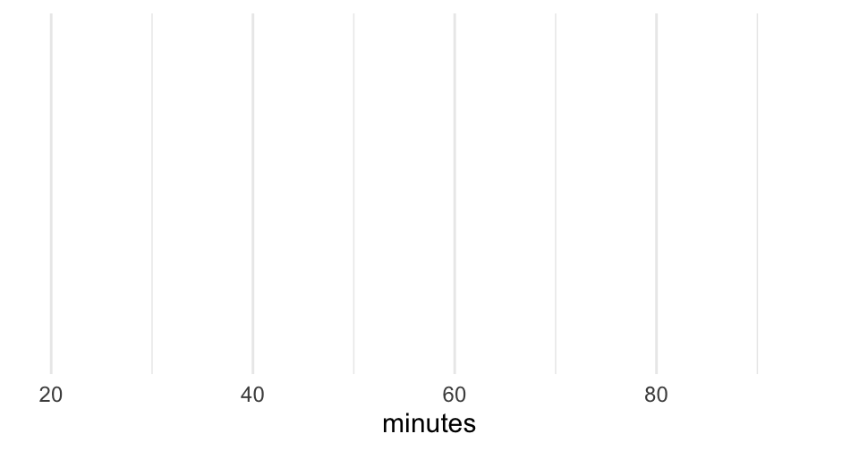

```r
ggplot(sessions_joined, aes(x = minutes))
```

Data and aesthetics alone give an empty canvas. We have not yet said what to draw.

## One numeric variable: the histogram

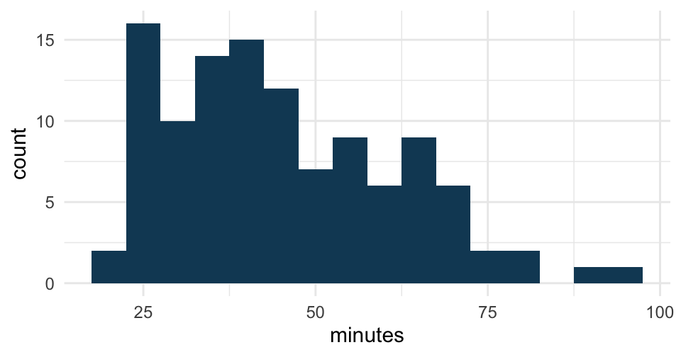

```r
ggplot(sessions_joined, aes(x = minutes)) +
  geom_histogram(binwidth = 5)
```

Each bar counts the sessions in a 5-minute range.

## The bin width is a choice

```r
ggplot(sessions_joined, aes(x = minutes)) +
  geom_histogram(binwidth = 1) +
  labs(title = "binwidth = 1: too fine")
```

```r
ggplot(sessions_joined, aes(x = minutes)) +
  geom_histogram(binwidth = 30) +
  labs(title = "binwidth = 30: too coarse")
```

Predict first: too narrow shows noise, too wide hides the shape. Run it, then try several widths.

## The bin width is a choice

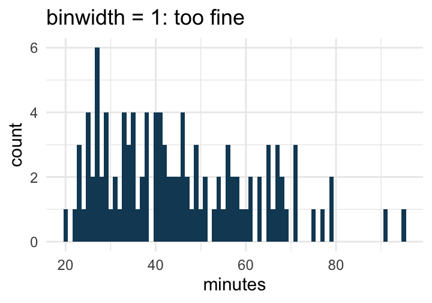

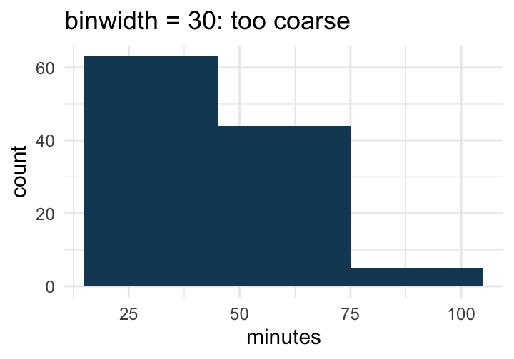

## Reading a histogram

Look for:

1. **Centre:** where is the bulk?
2. **Spread:** how wide?
3. **Shape:** one hump or two? A long tail on one side?
4. **Unusual values:** anything far from the rest?

Here: most sessions run 20 to 50 minutes, with a thin tail of long sessions to the **right**. This is **right-skewed**.

That tail is why the mean (above) sits higher than the median.

## A numeric variable by group: the boxplot

[figure not shown]

The box holds the middle half of the values. The line inside is the median. The whiskers and points show the rest.

## Boxplot of pace by squad

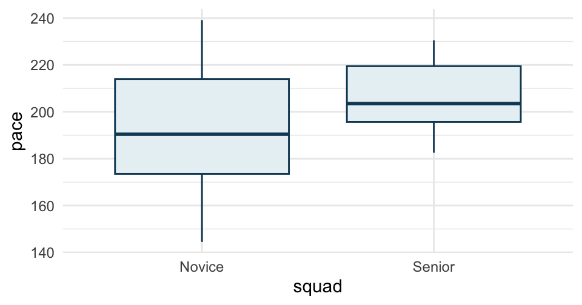

```r
ggplot(sessions_joined, aes(x = squad, y = pace)) +
  geom_boxplot()
```

Compare the **medians** (the lines), then the **spreads** (the heights of the boxes), then the **overlap**.

## Two numeric variables: the scatterplot

```
Warning: Removed 6 rows containing missing values or values outside the scale range
(`geom_point()`).
```

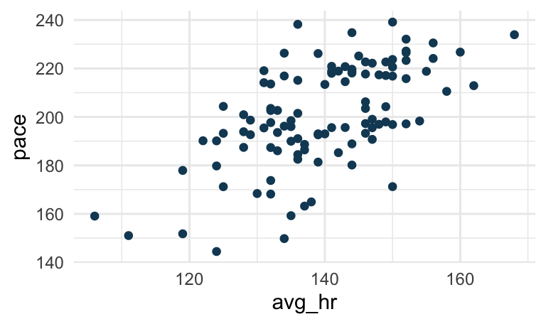

```r
ggplot(sessions_joined, aes(x = avg_hr, y = pace)) +
  geom_point()
```

R warns: **6 rows removed** because `avg_hr` is missing. The plot rests on 106 sessions, and we should say so.

## Make the plot say something

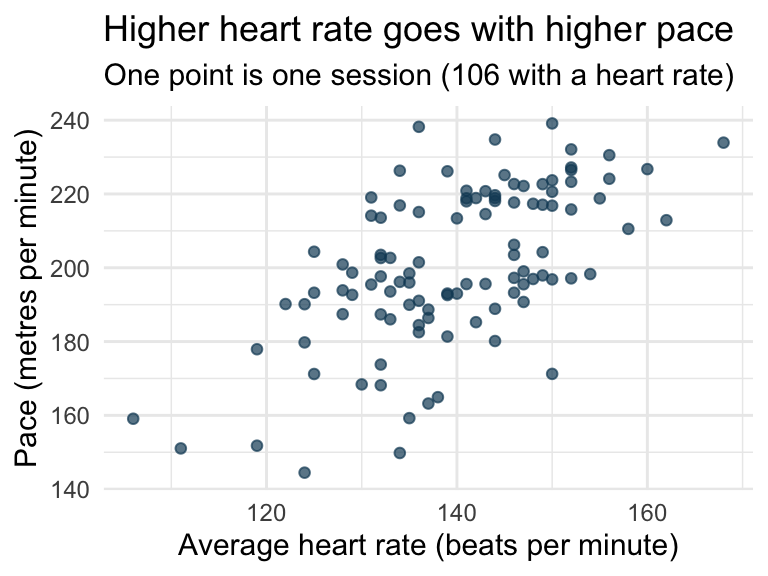

```r
ggplot(sessions_joined, aes(x = avg_hr, y = pace)) +
  geom_point(alpha = 0.7) +
  labs(
    title    = "Higher heart rate goes with higher pace",
    subtitle = "One point is one session (106 with a heart rate)",
    x        = "Average heart rate (beats per minute)",
    y        = "Pace (metres per minute)"
  )
```

A title states the finding. Axes carry units. The subtitle says what a point is and how many there are.

## Add a third variable with colour

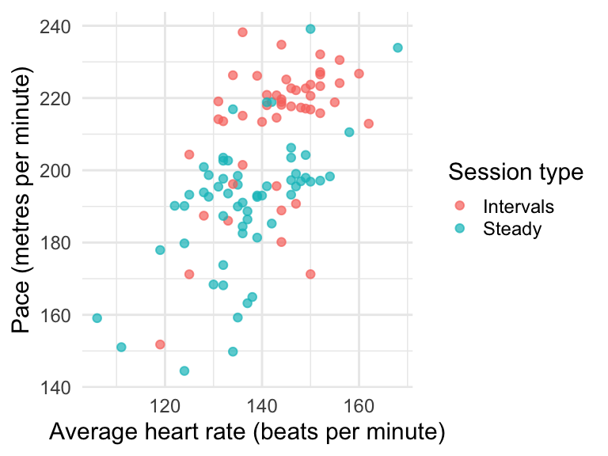

```r
ggplot(sessions_joined, aes(x = avg_hr, y = pace, colour = session_type)) +
  geom_point(alpha = 0.7) +
  labs(
    x      = "Average heart rate (beats per minute)",
    y      = "Pace (metres per minute)",
    colour = "Session type"
  )
```

Two clusters appear. The pattern across all sessions comes partly from **mixing two kinds of session**.

## How strong is the association?

```r
cor(sessions_joined$avg_hr, sessions_joined$pace, use = "complete.obs")
```

```
[1] 0.604443
```

A correlation near +0.6 is a moderate positive association. `use = "complete.obs"` drops the 6 missing pairs, as the plot did.

> **Association is not cause.** Harder sessions raise heart rate and pace together. Neither has to cause the other.

# Charts can mislead

## Misleading 1: a truncated axis

```r
by_squad <- sessions_joined |>
  group_by(squad) |>
  summarise(mean_pace = mean(pace))

ggplot(by_squad, aes(x = squad, y = mean_pace)) +
  geom_col() +
  coord_cartesian(ylim = c(185, 205)) +
  labs(title = "Misleading: axis starts at 185")
```

```r
ggplot(by_squad, aes(x = squad, y = mean_pace)) +
  geom_col() +
  labs(title = "Honest: axis starts at 0")
```

Bars encode length, so the axis must start at zero. Compare how big the gap between squads looks in each plot.

## Misleading 1: a truncated axis

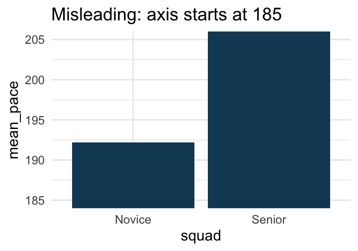

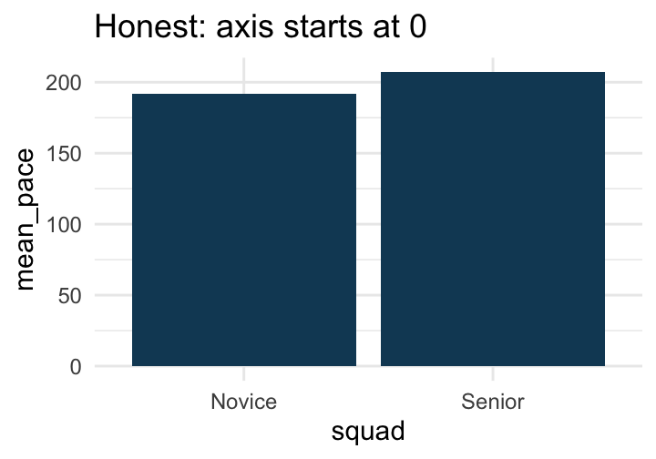

## Misleading 2: a mean with no spread

```r
ggplot(by_squad, aes(x = squad, y = mean_pace)) +
  geom_col() +
  labs(title = "Mean only")
```

```r
ggplot(sessions_joined, aes(x = squad, y = pace)) +
  geom_boxplot() +
  labs(title = "Median, spread and overlap")
```

A bar of means says nothing about spread or overlap. What does the boxplot show that the bars cannot?

## Misleading 2: a mean with no spread

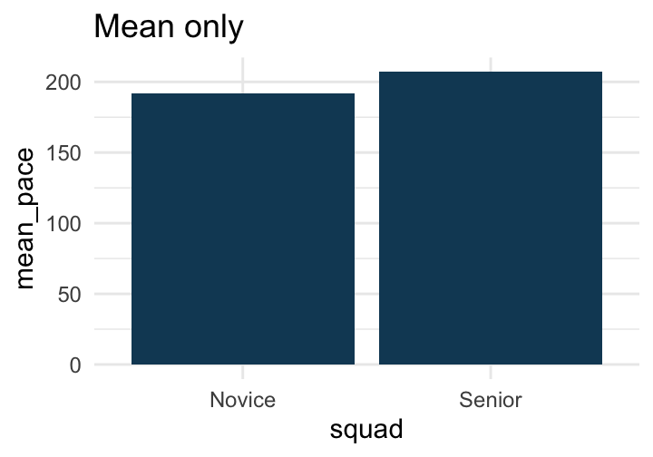

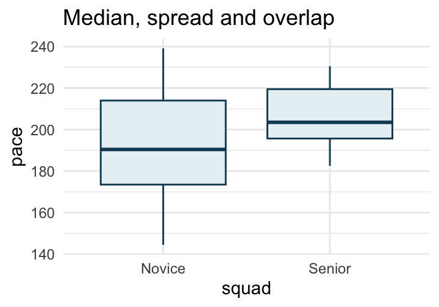

## Misleading 3: too much at once

```r
ggplot(sessions_joined,
       aes(x = avg_hr, y = pace, colour = rower_id,
           shape = squad, size = minutes)) +
  geom_point() +
  labs(title = "Too much: four extra encodings")
```

```r
ggplot(sessions_joined, aes(x = avg_hr, y = pace)) +
  geom_point(alpha = 0.7) +
  labs(title = "One idea")
```

If the reader cannot say what a plot shows in one sentence, simplify it.

## Misleading 3: too much at once

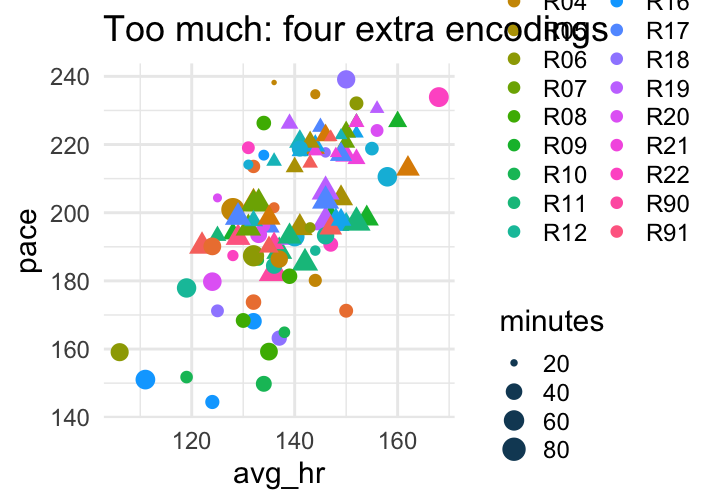

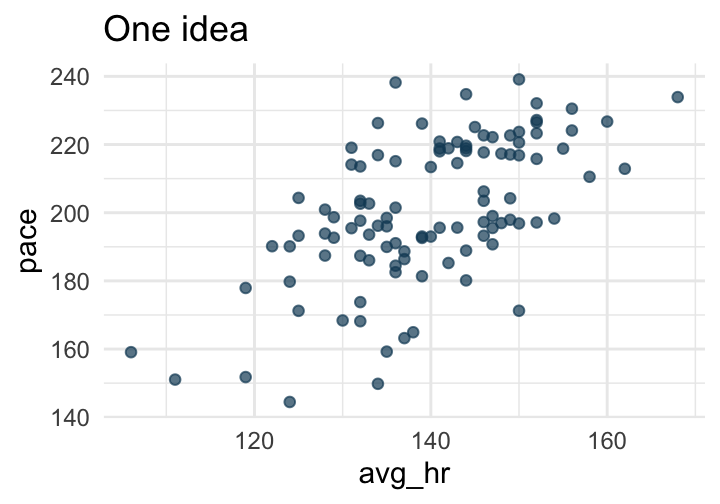

## A checklist for any plot

- Does the **title** state what the plot shows?
- Are the **axes labelled**, with units?
- Does it say **what a point or bar is**, and **how many**?
- Does it say **how many values were removed** because they were missing?
- Do bars **start at zero**?
- Is it **one idea**?

# Step 8: Communicate

## Build a careful sentence from the numbers

```r
by_type <- sessions_joined |>
  group_by(session_type) |>
  summarise(median_pace = round(median(pace)))

fast <- by_type$median_pace[by_type$session_type == "Intervals"]
slow <- by_type$median_pace[by_type$session_type == "Steady"]
n_hr <- sum(!is.na(sessions_joined$avg_hr))
r_hr <- cor(sessions_joined$avg_hr, sessions_joined$pace, use = "complete.obs")

sentence <- paste0(
  "Across ", nrow(sessions_joined), " sessions, Intervals sessions tend to be faster ",
  "than Steady sessions (median ", fast, " against ", slow, " metres a minute). ",
  "Higher average heart rate goes with higher pace (r = ", sprintf("%.2f", r_hr), ", ",
  n_hr, " sessions with a heart rate), but this does not show that one causes the other."
)

cat(sentence, fill = TRUE)
```

```
Across 112 sessions, Intervals sessions tend to be faster than Steady sessions (median 218 against 193 metres a minute). Higher average heart rate goes with higher pace (r = 0.60, 106 sessions with a heart rate), but this does not show that one causes the other.
```

## What makes it careful

> Across **112** sessions, Intervals sessions **tend to be** faster than Steady sessions. Higher heart rate **goes with** higher pace (r = 0.60, **106** sessions), but this **does not show** a cause.
- A **number** and a **count**: how much, from how many
- A **tentative verb**: tend to, goes with, is consistent with
- **No cause** unless the design supports one

## Say what you did

Your reader should be able to repeat your work.

- The rows you started and ended with (116 to 112), and why
- How the tables were joined, and what did not match (3 sessions)
- How many values each summary or plot rests on (106 with a heart rate)

# Where this goes

## Same grammar, more striking plots

The next six plots use the same ideas you have just used: **data, aesthetics, a geom, labels**.

- **All the data are invented.** No real athletes.
- You are not expected to write code like this yet.
- Copy a snippet, run it, then change **one small thing** (a colour, a title, a number) and run it again.

First time only, install two extra packages:

```r
install.packages(c("ggridges", "ggrepel"))
```

```r
library(ggridges)
library(ggrepel)
set.seed(6)
navy   <- "#124864"
accent <- "#d9822b"
```

## A pitch map

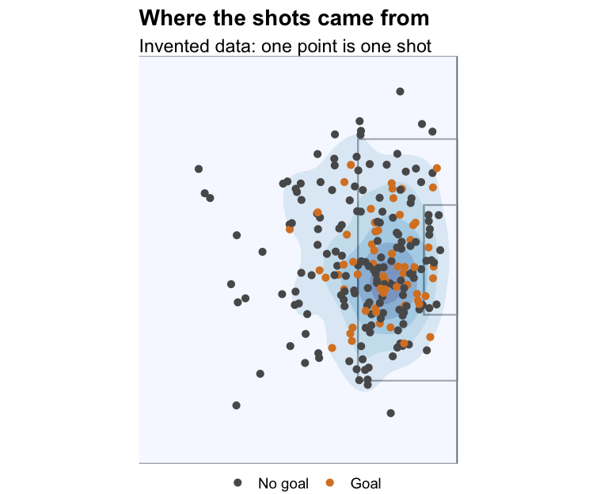

```r
shots <- tibble(
  x = 105 - rgamma(220, shape = 3.2, scale = 5.2),
  y = 34 + rnorm(220, 0, 11)
) |>
  filter(x > 55, y > 2, y < 66) |>
  mutate(goal = runif(n()) <
           plogis(-1.2 + 0.055 * (x - 80) - 0.05 * abs(y - 34)))

ggplot(shots, aes(x, y)) +
  annotate("rect", xmin = 0, xmax = 105, ymin = 0, ymax = 68,
           fill = NA, colour = "grey40") +
  annotate("rect", xmin = 88.5, xmax = 105, ymin = 13.85, ymax = 54.15,
           fill = NA, colour = "grey40") +
  annotate("rect", xmin = 99.5, xmax = 105, ymin = 24.85, ymax = 43.15,
           fill = NA, colour = "grey40") +
  stat_density_2d_filled(alpha = 0.55, bins = 6, show.legend = FALSE) +
  geom_point(aes(colour = goal), size = 2) +
  scale_fill_brewer(palette = "Blues") +
  scale_colour_manual(values = c("grey35", accent),
                      labels = c("No goal", "Goal"), name = NULL) +
  coord_fixed(xlim = c(52, 107), ylim = c(0, 68), expand = FALSE) +
  labs(title = "Where the shots came from",
       subtitle = "Invented data: one point is one shot") +
  theme_void(base_size = 14) +
  theme(plot.title = element_text(face = "bold"),
        legend.position = "bottom")
```

## Ridgelines: the whole distribution of each group

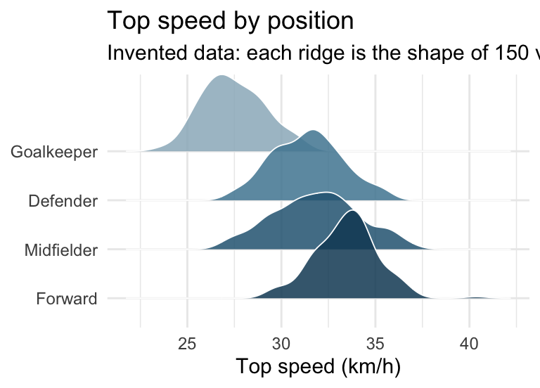

```r
speeds <- tibble(
  position = rep(c("Goalkeeper", "Defender", "Midfielder", "Forward"),
                 each = 150),
  top_speed = c(rnorm(150, 27.5, 1.6), rnorm(150, 31.2, 1.9),
                rnorm(150, 31.8, 2.1), rnorm(150, 33.4, 1.8))
) |>
  mutate(position = fct_relevel(position, "Goalkeeper", "Defender",
                                "Midfielder", "Forward"))

ggplot(speeds, aes(x = top_speed, y = fct_rev(position), fill = position)) +
  geom_density_ridges(alpha = 0.85, colour = "white", show.legend = FALSE) +
  scale_fill_manual(values = c("#9bb6c4", "#4f86a1", "#2a6482", navy)) +
  labs(title = "Top speed by position",
       subtitle = "Invented data: each ridge is the shape of 150 values",
       x = "Top speed (km/h)", y = NULL)
```

## Small multiples: the same plot for every athlete

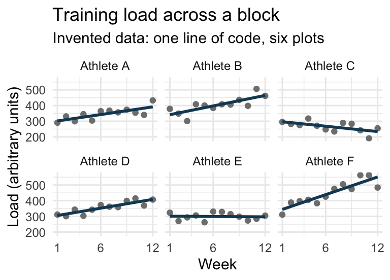

```r
load <- expand_grid(athlete = paste("Athlete", LETTERS[1:6]), week = 1:12) |>
  mutate(trend = rep(c(0.5, 1.2, -0.3, 0.8, 0, 1.8), each = 12),
         load = 300 + trend * 12 * week + rnorm(n(), 0, 30))

ggplot(load, aes(week, load)) +
  geom_point(colour = "grey50") +
  geom_smooth(method = "lm", se = FALSE, colour = navy) +
  facet_wrap(~athlete, nrow = 2) +
  scale_x_continuous(breaks = c(1, 6, 12)) +
  labs(title = "Training load across a block",
       subtitle = "Invented data: one line of code, six plots",
       x = "Week", y = "Load (arbitrary units)")
```

## A heatmap: many athletes, many weeks, one glance

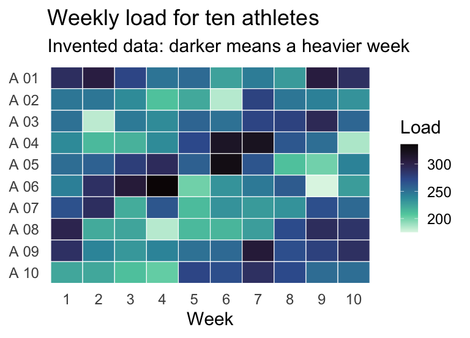

```r
heat <- expand_grid(athlete = paste("A", sprintf("%02d", 1:10)),
                    week = 1:10) |>
  mutate(load = pmax(0, 250 +
                       35 * sin(week / 1.6 + as.integer(factor(athlete))) +
                       rnorm(n(), 0, 25)))

ggplot(heat, aes(factor(week), fct_rev(athlete), fill = load)) +
  geom_tile(colour = "white") +
  scale_fill_viridis_c(option = "mako", direction = -1, name = "Load") +
  labs(title = "Weekly load for ten athletes",
       subtitle = "Invented data: darker means a heavier week",
       x = "Week", y = NULL) +
  theme(panel.grid = element_blank())
```

## A dumbbell chart: before and after

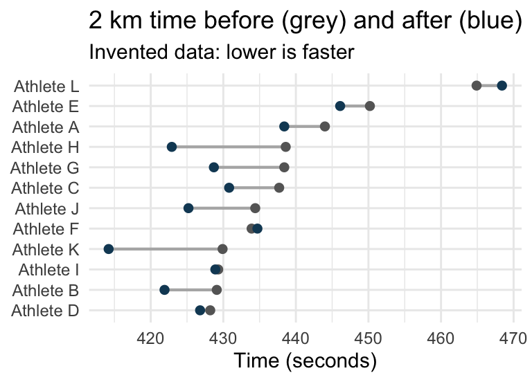

```r
change <- tibble(athlete = paste("Athlete", LETTERS[1:12]),
                 before = round(rnorm(12, 430, 14), 1)) |>
  mutate(after = round(before - rnorm(12, 7, 5), 1),
         athlete = fct_reorder(athlete, before))

ggplot(change, aes(y = athlete)) +
  geom_segment(aes(x = after, xend = before, yend = athlete),
               colour = "grey70", linewidth = 1.2) +
  geom_point(aes(x = before), colour = "grey40", size = 3) +
  geom_point(aes(x = after), colour = navy, size = 3) +
  labs(title = "2 km time before (grey) and after (blue)",
       subtitle = "Invented data: lower is faster",
       x = "Time (seconds)", y = NULL)
```

## An annotated plot: the story is on the plot

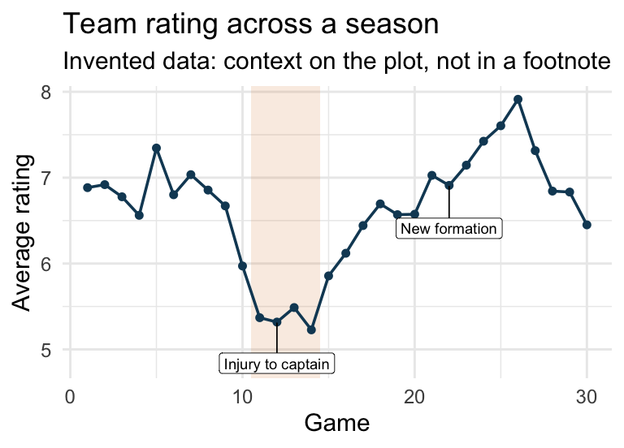

```r
season <- tibble(game = 1:30) |>
  mutate(rating = 6.4 + 0.012 * game + 0.5 * sin(game / 3) +
           rnorm(30, 0, 0.25),
         rating = if_else(game %in% 11:14, rating - 0.8, rating))

notes <- tibble(game = c(12, 22),
                rating = c(season$rating[12], season$rating[22]),
                label = c("Injury to captain", "New formation"))

ggplot(season, aes(game, rating)) +
  annotate("rect", xmin = 10.5, xmax = 14.5, ymin = -Inf, ymax = Inf,
           fill = accent, alpha = 0.15) +
  geom_line(colour = navy, linewidth = 1) +
  geom_point(colour = navy, size = 2) +
  geom_label_repel(data = notes, aes(label = label),
                   nudge_y = -0.5, min.segment.length = 0) +
  labs(title = "Team rating across a season",
       subtitle = "Invented data: context on the plot, not in a footnote",
       x = "Game", y = "Average rating")
```

# Your turn

## Repeat the workflow on a cycling case

Same steps, new data. Use the **Week 6 Task Sheet**.

| Step | Do this | Tools |
| --- | --- | --- |
| 1 Understand | What is one row in each table? | `glimpse()` |
| 2 Trust | Missing, repeated, labels, plausible? | `colSums(is.na())`, `duplicated()`, `count()`, `slice_max()` |
| 3 Clean | Fix, remove, and write down | `str_to_title()`, `distinct()`, `filter()` |
| 4 Connect | Plan, join, check | `left_join()`, `anti_join()`, `nrow()` |
| 5 Transform | Total or rate? | `mutate()`, `group_by()`, `summarise()` |
| 6 Numbers | Centre, spread, missing | `median()`, `IQR()`, `na.rm = TRUE` |
| 7 Plots | Histogram, boxplot, scatterplot | `ggplot()` |
| 8 Communicate | One careful sentence | number, count, tentative verb |

## Before you leave

- Your script runs from top to bottom without errors
- You wrote down what you changed in the data and why
- Every plot has a title that states a finding, labelled axes, and a count

Week 7 is reading week. Assessment One is in Week 8.